# FML_Assignment_2_KNN

2023-09-29

# Summary

This assignment has the k Nearest Neighbour (KNN) classification code for Universal Bank

## Questions - Answers

1. How would this customer be classified? - This new customer would be classified as 0, does not take the personal loan.
2. What is a choice of k that balances between overfitting and ignoring the predictor information? - The best K is 3
3. Show the confusion matrix for the validation data that results from using the best k.

   ```
                  Reference
      Prediction    0    1
      0             1814  53
      1             10    123

      Sensitivity : 0.6989
      Specificity : 0.9945
      Pos Pred Value : 0.9248
      Neg Pred Value : 0.9716
   ```

4. Classify the customer using the best k - This new customer would be classified as 0, does not take the personal loan.
5. Repartition the data, this time into training, validation, and test sets (50% : 30% : 20%). Apply the k-NN method with the k chosen above. Compare the confusion matrix of the test set. with that of the training and validation sets. Comment on the differences and their reason? -

   Firstly, the accuracy/Sensitivity for train vs train is high, because the model memorize the data set and yield the better results.

   Secondly, train vs test has the good results because the training model trains on 50% of data and test it on 20% unseen data.

   Finally, train vs valid displays the confusion matrix results based on 50% training data and 30% unseen validation data.

   The results of the confusion matrices varies based on the random sample taken it training, validation, test sets.

## Problem Statement

Universal bank is a young bank growing rapidly in terms of overall customer acquisition. The majority of these customers are liability customers (depositors) with varying sizes of relationship with the bank. The customer base of asset customers (borrowers) is quite small, and the bank is interested in expanding this base rapidly in more loan business. In particular, it wants to explore ways of converting its liability customers to personal loan customers.

A campaign that the bank ran last year for liability customers showed a healthy conversion rate of over 9% success. This has encouraged the retail marketing department to devise smarter campaigns with better target marketing. The goal is to use k-NN to predict whether a new customer will accept a loan offer. This will serve as the basis for the design of a new campaign.

The file UniversalBank.csv contains data on 5000 customers. The data include customer demographic information (age, income, etc.), the customer’s relationship with the bank (mortgage, securities account, etc.), and the customer response to the last personal loan campaign (Personal Loan). Among these 5000 customers, only 480 (= 9.6%) accepted the personal loan that was offered to them in the earlier campaign.

Partition the data into training (60%) and validation (40%) sets

### Data Import and Cleaning

First, load the required libraries

```r
library(class)
library(caret)
library(e1071)
```

Read the data.

```r
setwd("C:/Users/user/Documents/R/FML/Assignment2_FML")
universal.df <- read.csv("UniversalBank.csv")
dim(universal.df)
```

```
## [1] 5000   14
```

```r
t(t(names(universal.df))) # The t function creates a transpose of the dataframe
```

```
##       [,1]
##  [1,] "ID"
##  [2,] "Age"
##  [3,] "Experience"
##  [4,] "Income"
##  [5,] "ZIP.Code"
##  [6,] "Family"
##  [7,] "CCAvg"
##  [8,] "Education"
##  [9,] "Mortgage"
## [10,] "Personal.Loan"
## [11,] "Securities.Account"
## [12,] "CD.Account"
## [13,] "Online"
## [14,] "CreditCard"
```

Drop ID and ZIP

```r
universal.df <- universal.df[,-c(1,5)]
```

Split Data into 60% training and 40% validation. Before we split, let us transform categorical variables into dummy variables.

```r
# Only Education needs to be converted to factor

universal.df$Education <- as.factor(universal.df$Education)

# Now, converting Education to Dummy Variables

groups <- dummyVars(~., data = universal.df) # This creates the dummy groups
universal_m.df <- as.data.frame(predict(groups,universal.df))

# Important to ensure that we get the same sample if we rerun the code

set.seed(7)

#Partitioning the data - 60% training; 40% validation

train.index <- sample(row.names(universal_m.df), 0.6*dim(universal_m.df)[1])
valid.index <- setdiff(row.names(universal_m.df), train.index)

train.df <- universal_m.df[train.index,]
valid.df <- universal_m.df[valid.index,]
t(t(names(train.df)))
```

```
##       [,1]
##  [1,] "Age"
##  [2,] "Experience"
##  [3,] "Income"
##  [4,] "Family"
##  [5,] "CCAvg"
##  [6,] "Education.1"
##  [7,] "Education.2"
##  [8,] "Education.3"
##  [9,] "Mortgage"
## [10,] "Personal.Loan"
## [11,] "Securities.Account"
## [12,] "CD.Account"
## [13,] "Online"
## [14,] "CreditCard"
```

Now, let us normalize the data

```r
train.norm.df <- train.df[,-10] # Note that Personal Income is the 10th variable
valid.norm.df <- valid.df[,-10]

#Center is Avg, Scale is STDEV
#Once we have this values, we can apply them to any model

norm.values <- preProcess(train.df[, -10], method=c("center", "scale"))

train.norm.df <- predict(norm.values, train.df[, -10])
valid.norm.df <- predict(norm.values, valid.df[, -10])
```

Values in all attributes are normalized to common scale i.e., Standard Deviation Scale.

### Questions

Consider the following customer:

1. Age = 40, Experience = 10, Income = 84, Family = 2, CCAvg = 2, Education_1 = 0, Education_2 = 1, Education_3 = 0, Mortgage = 0, Securities Account = 0, CD Account = 0, Online = 1, and Credit Card = 1. Perform a k-NN classification with all predictors except ID and ZIP code using k = 1. Remember to transform categorical predictors with more than two categories into dummy variables first. Specify the success class as 1 (loan acceptance), and use the default cutoff value of 0.5. How would this customer be classified?

```r
# We have converted all categorical variables to dummy variables
# Let's create a new sample
new_customer <- data.frame(
  Age = 40,
  Experience = 10,
  Income = 84,
  Family = 2,
  CCAvg = 2,
  Education.1 = 0,
  Education.2 = 1,
  Education.3 = 0,
  Mortgage = 0,
  Securities.Account = 0,
  CD.Account = 0,
  Online = 1,
  CreditCard = 1
)

# Normalize the new customer
new.cust.norm <- new_customer
new.cust.norm <- predict(norm.values, new.cust.norm)
```

Now, let us predict using knn

```r
knn.predict <- class::knn(train = train.norm.df,
                       test = new.cust.norm,
                       cl = train.df$Personal.Loan, k = 1)
knn.predict
```

```
## [1] 0
## Levels: 0 1
```

Given knn.predict classified as 0, new customer doesn’t take personal loan

2. What is a choice of k that balances between overfitting and ignoring the predictor information?

```r
# Calculate the accuracy for each value of k
# Set the range of k values to consider

accuracy.df <- data.frame(k = seq(1, 15, 1), overallaccuracy = rep(0, 15))

for(i in 1:15) {
  knn.predict <- class::knn(train = train.norm.df,
                         test = valid.norm.df,
                         cl = train.df$Personal.Loan, k = i)
  accuracy.df[i, 2] <- confusionMatrix(knn.predict,
                                       as.factor(valid.df$Personal.Loan),positive = "1")$overall[1]
}

cat("The best k value with max accuracy is", which(accuracy.df[,2] == max(accuracy.df[,2])))
```

```
## The best k value with max accuracy is 3
```

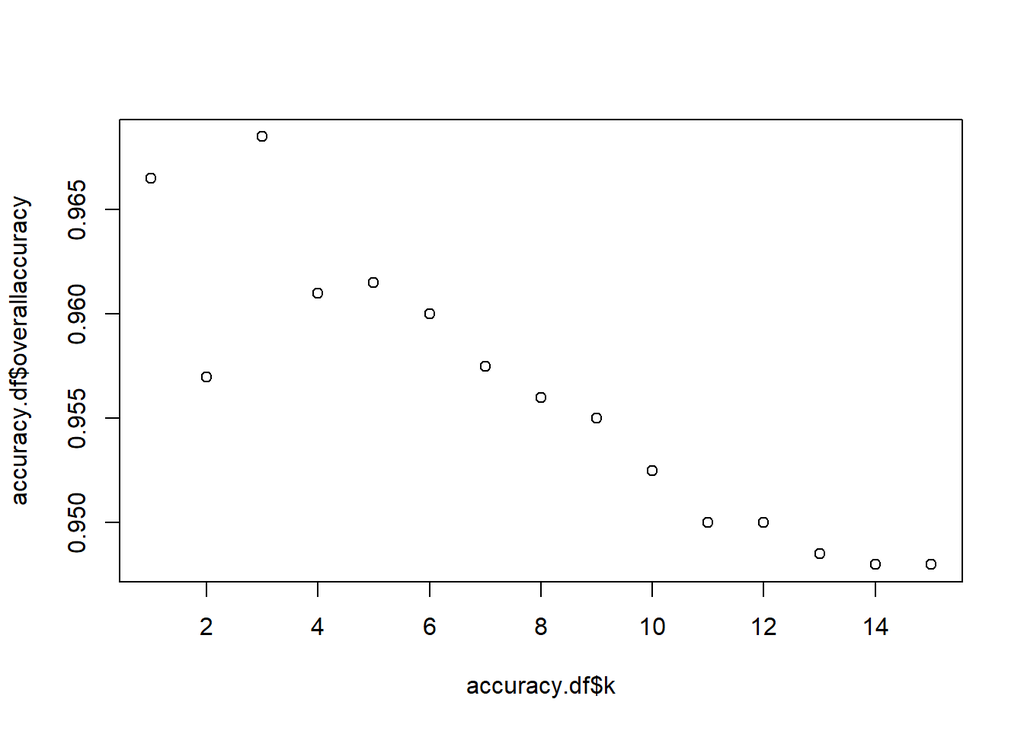

```r
#Plotting a graph with training vs validation set

plot(accuracy.df$k,accuracy.df$overallaccuracy)
```

3. Show the confusion matrix for the validation data that results from using the best k.

```r
knn.predict.1 <- class::knn(train = train.norm.df,
                         test = valid.norm.df,
                         cl = train.df$Personal.Loan, k = 3) #best k value taken from above
accuracy.df <- confusionMatrix(knn.predict.1, as.factor(valid.df$Personal.Loan),positive = "1")

accuracy.df
```

```
## Confusion Matrix and Statistics
##
##           Reference
## Prediction    0    1
##          0 1814   53
##          1   10  123
##
##                Accuracy : 0.9685
##                  95% CI : (0.9599, 0.9757)
##     No Information Rate : 0.912
##     P-Value [Acc > NIR] : < 2.2e-16
##
##                   Kappa : 0.7794
##
##  Mcnemar's Test P-Value : 1.213e-07
##
##             Sensitivity : 0.6989
##             Specificity : 0.9945
##          Pos Pred Value : 0.9248
##          Neg Pred Value : 0.9716
##              Prevalence : 0.0880
##          Detection Rate : 0.0615
##    Detection Prevalence : 0.0665
##       Balanced Accuracy : 0.8467
##
##        'Positive' Class : 1
##
```

4. Consider the following customer: Age = 40, Experience = 10, Income = 84, Family = 2, CCAvg = 2, Education_1 = 0, Education_2 = 1, Education_3 = 0, Mortgage = 0, Securities Account = 0, CD Account = 0, Online = 1 and Credit Card = 1. Classify the customer using the best k.

```r
#new.cust.norm was assigned with above mentioned customer details

knn.predict.2 <- class::knn(train = train.norm.df,
                       test = new.cust.norm,
                       cl = train.df$Personal.Loan, k = 3) #best k is taken from Answer 2
knn.predict.2
```

```
## [1] 0
## Levels: 0 1
```

As the output is 0 with best k, the new customer doesn’t take personal loan.

5. Repartition the data, this time into training, validation, and test sets (50% : 30% : 20%). Apply the k-NN method with the k chosen above. Compare the confusion matrix of the test set with that of the training and validation sets. Comment on the differences and their reason.

```r
set.seed(7)  # Important to ensure that we get the same sample if we rerun the code

#Partitioning 50% to training set, 30% to validation set, 20% to test set

train.index.1 <- sample(row.names(universal_m.df), 0.5*dim(universal_m.df)[1])
valid.index.1 <- sample(setdiff(row.names(universal_m.df), train.index.1),0.3*dim(universal_m.df)[1])
test.index.1 <- setdiff(row.names(universal_m.df), c(train.index.1, valid.index.1))

train.df.1 <- universal_m.df[train.index.1,]
valid.df.1 <- universal_m.df[valid.index.1,]
test.df.1 <- universal_m.df[test.index.1,]
t(t(names(train.df.1)))
```

```
##       [,1]
##  [1,] "Age"
##  [2,] "Experience"
##  [3,] "Income"
##  [4,] "Family"
##  [5,] "CCAvg"
##  [6,] "Education.1"
##  [7,] "Education.2"
##  [8,] "Education.3"
##  [9,] "Mortgage"
## [10,] "Personal.Loan"
## [11,] "Securities.Account"
## [12,] "CD.Account"
## [13,] "Online"
## [14,] "CreditCard"
```

Now, let us normalize the data

```r
train.norm.df.1 <- train.df.1[,-10] # Note that Personal Income is the 10th variable
valid.norm.df.1 <- valid.df.1[,-10]
test.norm.df.1 <- test.df.1[,-10]

norm.values.1 <- preProcess(train.df.1[, -10], method=c("center", "scale"))

train.norm.df.1 <- predict(norm.values.1, train.df.1[, -10])
valid.norm.df.1 <- predict(norm.values.1, valid.df.1[, -10])
test.norm.df.1 <- predict(norm.values.1, test.df.1[, -10])
```

Now, let us predict using knn

```r
knn.predict.3 <- class::knn(train = train.norm.df.1,
                       test = new.cust.norm,
                       cl = train.df.1$Personal.Loan, k = 3)
knn.predict.3
```

```
## [1] 0
## Levels: 0 1
```

After Repartition the data into 50% training; 30% validation; 20% test sets, the knn still classifies as 0. Which means the new customer doesn’t take personal loan

Now, build a confusion matrices for train, valid, test sets.

```r
# Calculate the accuracy for each value of k
# Set the range of k values to consider

accuracy.df.1 <- data.frame(k = seq(1, 15, 1), overallaccuracy = rep(0, 15))

#train vs test set

knn.predict.4 <- class::knn(train = train.norm.df.1,
                         test = test.norm.df.1,
                         cl = train.df.1$Personal.Loan, k = 3)
accuracy.df.1 <- confusionMatrix(knn.predict.4, as.factor(test.df.1$Personal.Loan),positive = "1")


accuracy.df.1 #Displays the confusion matrix
```

```
## Confusion Matrix and Statistics
##
##           Reference
## Prediction   0   1
##          0 914  27
##          1   5  54
##
##                Accuracy : 0.968
##                  95% CI : (0.9551, 0.978)
##     No Information Rate : 0.919
##     P-Value [Acc > NIR] : 1.325e-10
##
##                   Kappa : 0.7547
##
##  Mcnemar's Test P-Value : 0.0002054
##
##             Sensitivity : 0.6667
##             Specificity : 0.9946
##          Pos Pred Value : 0.9153
##          Neg Pred Value : 0.9713
##              Prevalence : 0.0810
##          Detection Rate : 0.0540
##    Detection Prevalence : 0.0590
##       Balanced Accuracy : 0.8306
##
##        'Positive' Class : 1
##
```

```r
accuracy.df.2 <- data.frame(k = seq(1, 15, 1), overallaccuracy = rep(0, 15))

# train vs valid

knn.predict.5 <- class::knn(train = train.norm.df.1,
                         test = valid.norm.df.1,
                         cl = train.df.1$Personal.Loan, k = 3)
accuracy.df.2 <- confusionMatrix(knn.predict.5, as.factor(valid.df.1$Personal.Loan),positive = "1")


accuracy.df.2 #Displays the confusion matrix
```

```
## Confusion Matrix and Statistics
##
##           Reference
## Prediction    0    1
##          0 1344   49
##          1   11   96
##
##                Accuracy : 0.96
##                  95% CI : (0.9488, 0.9693)
##     No Information Rate : 0.9033
##     P-Value [Acc > NIR] : < 2.2e-16
##
##                   Kappa : 0.7406
##
##  Mcnemar's Test P-Value : 1.782e-06
##
##             Sensitivity : 0.66207
##             Specificity : 0.99188
##          Pos Pred Value : 0.89720
##          Neg Pred Value : 0.96482
##              Prevalence : 0.09667
##          Detection Rate : 0.06400
##    Detection Prevalence : 0.07133
##       Balanced Accuracy : 0.82698
##
##        'Positive' Class : 1
##
```

```r
accuracy.df.3 <- data.frame(k = seq(1, 15, 1), overallaccuracy = rep(0, 15))

# train vs train

knn.predict.6 <- class::knn(train = train.norm.df.1,
                         test = train.norm.df.1,
                         cl = train.df.1$Personal.Loan, k = 3)
accuracy.df.3 <- confusionMatrix(knn.predict.6, as.factor(train.df.1$Personal.Loan),positive = "1")


accuracy.df.3 #Displays the confusion matrix
```

```
## Confusion Matrix and Statistics
##
##           Reference
## Prediction    0    1
##          0 2243   62
##          1    3  192
##
##                Accuracy : 0.974
##                  95% CI : (0.967, 0.9799)
##     No Information Rate : 0.8984
##     P-Value [Acc > NIR] : < 2.2e-16
##
##                   Kappa : 0.8412
##
##  Mcnemar's Test P-Value : 6.291e-13
##
##             Sensitivity : 0.7559
##             Specificity : 0.9987
##          Pos Pred Value : 0.9846
##          Neg Pred Value : 0.9731
##              Prevalence : 0.1016
##          Detection Rate : 0.0768
##    Detection Prevalence : 0.0780
##       Balanced Accuracy : 0.8773
##
##        'Positive' Class : 1
##
```